# NEON ForestAGB — Allometry of Tree Growth: Initial Size vs Growth Rate

# 9 $\Delta D$ vs initial DBH: faceted by growth form

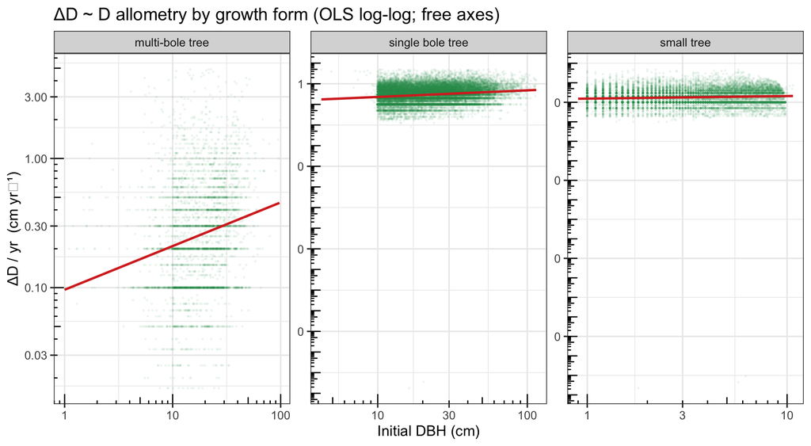

```r
pos_dbh |>
  filter(!is.na(growthForm), DBH_inc_cm_yr < 5) |>
  group_by(growthForm) |>
  filter(n() >= 100) |>
  ungroup() |>
  ggplot(aes(x = DBH_start, y = DBH_inc_cm_yr)) +
  geom_point(alpha = 0.06, size = 0.4, color = "#1a9850") +
  geom_smooth(method = "lm", formula = y ~ x,
              color = "#d73027", linewidth = 1, se = FALSE) +
  scale_x_log10(labels = comma) +
  scale_y_log10(labels = comma) +
  annotation_logticks() +
  facet_wrap(~ growthForm, scales = "free", ncol = 3) +
  labs(
    x = "Initial DBH (cm)", y = "\u0394D / yr  (cm yr\u207b\u00b9)",
    title = "\u0394D ~ D allometry by growth form (OLS log-log; free axes)"
  )
```

# 10 Top species: $\Delta D$ ~ initial DBH

For the 8 most frequently sampled species.

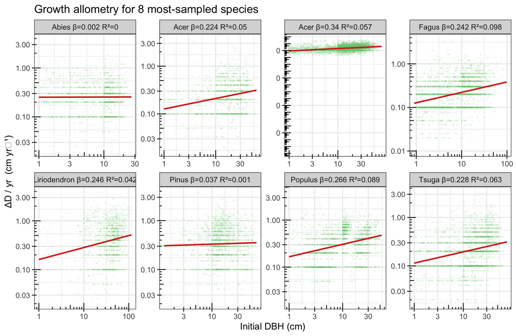

```r
top_sp <- pos_dbh |>
  filter(!is.na(scientificName)) |>
  count(scientificName, sort = TRUE) |>
  head(8) |>
  pull(scientificName)

sp_exp <- pos_dbh |>
  filter(scientificName %in% top_sp) |>
  group_by(scientificName) |>
  summarise(
    n    = n(),
    beta = round(coef(lm(log(DBH_inc_cm_yr) ~ log(DBH_start)))[2], 3),
    R2   = round(summary(lm(log(DBH_inc_cm_yr) ~ log(DBH_start)))$r.squared, 3),
    .groups = "drop"
  )

pos_dbh |>
  filter(scientificName %in% top_sp, DBH_inc_cm_yr < 4) |>
  left_join(sp_exp, by = "scientificName") |>
  mutate(label = paste0(gsub(" .*", "", scientificName),
                        " \u03b2=", beta, " R\u00b2=", R2)) |>
  ggplot(aes(x = DBH_start, y = DBH_inc_cm_yr)) +
  geom_point(alpha = 0.08, size = 0.5, color = "#74c476") +
  geom_smooth(method = "lm", formula = y ~ x,
              color = "#d73027", linewidth = 1, se = FALSE) +
  geom_hline(yintercept = NA) +
  scale_x_log10(labels = comma) +
  scale_y_log10(labels = comma) +
  annotation_logticks() +
  facet_wrap(~ label, scales = "free", ncol = 4) +
  labs(
    x = "Initial DBH (cm)", y = "\u0394D / yr  (cm yr\u207b\u00b9)",
    title = "Growth allometry for 8 most-sampled species"
  )
```

# 11 Caveats

1. **OLS on log-transformed data.** OLS underestimates the allometric slope when measurement error is present in both variables. SMA (standardised major axis) regression is preferred for formal allometric estimation.
2. **Positive-increment filter.** Log-log regressions require strictly positive $\Delta D$ and $\Delta M$. Excluding the 20% negative-increment intervals introduces a selection bias toward faster-growing or more accurately measured trees.
3. **AGB is model-derived.** All AGB values come from Chojnacky et al. (2014) applied to DBH. The $\Delta M \sim M^{\beta}$ relationship largely reflects the structure of the Chojnacky equations, not independent biomass measurements.
4. **Gap normalisation.** Growth is divided by the actual year gap between censuses (1–9 years), which is not uniform. Long gaps average over interannual variability.
5. **Mixed species and biomes.** All sites are pooled for overall regressions. Allometric exponents differ among species, forest types, and disturbance histories. Per-site and per-species analyses reveal this heterogeneity.
6. **Theory comparison.** MST predictions (WBE model, Enquist et al.) assume ideal self-similar vascular networks and no resource limitation other than light capture geometry. Real forests deviate from this for many reasons (competition, disturbance, drought, ontogenetic stage).